# PS5 Markdown Basic Plots Assignment

Shawna Nguyen

2023-02-18

## Part 1

### Question 1.2

```r
library(tidyverse)
world <- read_delim("gapminder.csv")
```

```r
world %>%
  dim()
```

```
## [1] 13055    25
```

The *world* data contains 13055 rows and 25 columns.

### Question 1.3

```r
world %>%
  sample_n(5) %>%
  knitr::kable()
```

| iso3 | name | iso2 | region | sub-region | intermediate-region | time | totalPopulation | fertilityRate | lifeExpectancy | childMortality | youthFemaleLiteracy | youthMaleLiteracy | adultLiteracy | GDP_PC | accessElectricity | agriculturalLand | agricultureTractors | cerealProduction | fertilizerHa | co2 | greenhouseGases | co2_PC | pm2.5_35 | battleDeaths |
| --- | --- | --- | --- | --- | --- | --- | --- | --- | --- | --- | --- | --- | --- | --- | --- | --- | --- | --- | --- | --- | --- | --- | --- | --- |
| IND | India | IN | Asia | Southern Asia | NA | 2005 | 1147609927 | 2.972 | 64.50000 | 74.5 | NA | NA | NA | 1040.312 | 67.09344 | 1801260 | NA | 239997492 | 127.6146 | 1222563.132 | 2117460.5900 | 1.06531 | 89.223 | 1382 |
| CYM | Cayman Islands | KY | Americas | Latin America and the Caribbean | Caribbean | 1987 | 21544 | NA | NA | NA | NA | NA | NA | NA | NA | 27 | NA | NA | NA | 216.353 | NA | 10.04238 | NA | NA |
| ARE | United Arab Emirates | AE | Asia | Western Asia | NA | 1976 | 637922 | 5.973 | 65.91600 | 53.1 | NA | NA | NA | 103766.654 | NA | 2160 | 152 | NA | 100.0000 | 39651.271 | 70352.6192 | 62.15693 | NA | NA |
| MUS | Mauritius | MU | Africa | Sub-Saharan Africa | Eastern Africa | 1979 | 949888 | 2.818 | 66.45578 | 43.9 | NA | NA | NA | 2628.349 | NA | 1140 | NA | 1209 | 274.3200 | 660.060 | 944.4867 | 0.69488 | NA | NA |
| ALB | Albania | AL | Europe | Southern Europe | NA | 1971 | 2187853 | 4.775 | 67.23700 | NA | NA | NA | NA | NA | NA | 12000 | 6700 | 547485 | 101.5094 | 4352.729 | 6950.0361 | 1.98950 | NA | NA |

## Part 2

### Question 2.1

```r
world %>%
  summarise(n = n_distinct(`iso3`))
```

```
## # A tibble: 1 × 1
##       n
##   <int>
## 1   253
```

There are 253 countries in the “iso3” dataset.

```r
world %>%
  summarise(n = n_distinct(`iso2`))
```

```
## # A tibble: 1 × 1
##       n
##   <int>
## 1   249
```

There are 249 countries in the “iso2” dataset.

```r
world %>%
  summarise(n = n_distinct(`name`))
```

```
## # A tibble: 1 × 1
##       n
##   <int>
## 1   250
```

There are 250 countries in the “name” dataset.

### Question 2.2.a

```r
world %>%
  group_by(iso2) %>%
  summarise(num = n_distinct(iso2)) %>%
  arrange(desc(num))
```

```
## # A tibble: 249 × 2
##    iso2    num
##    <chr> <int>
##  1 AD        1
##  2 AE        1
##  3 AF        1
##  4 AG        1
##  5 AI        1
##  6 AL        1
##  7 AM        1
##  8 AO        1
##  9 AQ        1
## 10 AR        1
## # … with 239 more rows
```

There is exactly one iso-2 code that corresponds to every country.

### Question 2.2.b

```r
world %>%
  group_by(name) %>%
  summarise(num = n_distinct(iso3)) %>%
  arrange(desc(num))
```

```
## # A tibble: 250 × 2
##    name                  num
##    <chr>               <int>
##  1 <NA>                    4
##  2 Afghanistan             1
##  3 Albania                 1
##  4 Algeria                 1
##  5 American Samoa          1
##  6 Andorra                 1
##  7 Angola                  1
##  8 Anguilla                1
##  9 Antarctica              1
## 10 Antigua and Barbuda     1
## # … with 240 more rows
```

```r
world %>%
  select(iso3) %>%
  filter(iso3 == c("CHANISL", "GBM", "KOS", "NLD_CURACAO")) %>%
  group_by(iso3) %>%
  sample_n(1)
```

```
## # A tibble: 4 × 1
## # Groups:   iso3 [4]
##   iso3
##   <chr>
## 1 CHANISL
## 2 GBM
## 3 KOS
## 4 NLD_CURACAO
```

The countries that have more than one iso-3 code are CHANISL, GBM, KOS and NLD CURACAO.

### Question 2.3

```r
world %>%
  filter(!is.na(time)) %>%
  summarise(min=min(time), max=max(time))
```

```
## # A tibble: 1 × 2
##     min   max
##   <dbl> <dbl>
## 1  1960  2019
```

The latest year that this dataframe dates back to is 1960, while the most recent year is 2019.

## Part 3

### Question 3.1

```r
world %>%
  group_by(time) %>%
  filter(is.na(co2), is.na(co2_PC)) %>%
  count() %>%
  arrange(desc(n))
```

```
## # A tibble: 61 × 2
## # Groups:   time [61]
##     time     n
##    <dbl> <int>
##  1  2017   217
##  2  2018   217
##  3  2019   217
##  4  1960    60
##  5  1961    60
##  6  1962    58
##  7  1963    57
##  8  1964    51
##  9  1965    51
## 10  1966    51
## # … with 51 more rows
```

The years that have the most missing data is 2017, 2018 and 2019 with 217 NA’s.

### Question 3.2

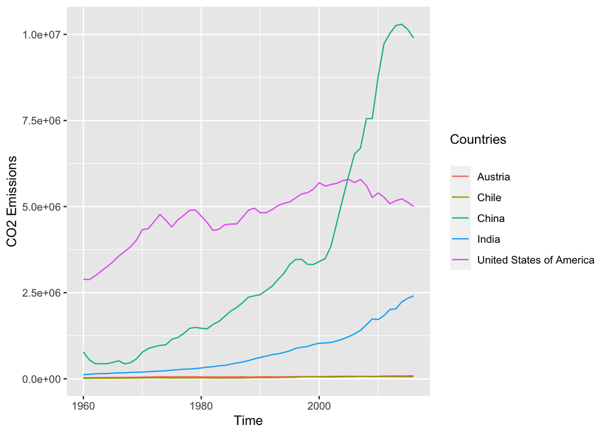

```r
world %>%
  filter(!is.na(co2)) %>%
  filter(name == "United States of America" | name == "China" | name == "India" | name == "Chile" | name == "Austria") %>%
  ggplot(aes(time, co2, col=factor(name))) +
  geom_line() +
  labs(x = "Time", y = "CO2 Emissions", col = "Countries\n")
```

### Question 3.3

(5pt) Now let’s analyze the CO2 emissions per capita (co2_PC). Make a similar plot of the same countries. What does this figure suggest?

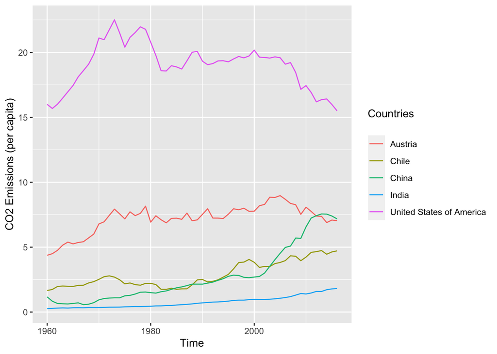

```r
world %>%
  filter(!is.na(co2_PC)) %>%
  filter(name == "United States of America" | name == "China" | name == "India" | name == "Chile" | name == "Austria") %>%
  ggplot(aes(time, co2_PC, col=factor(name))) +
  geom_line() +
  labs(x = "Time", y = "CO2 Emissions (per capita)", col = "Countries\n")
```

After analyzing the line plot above, it tells me that the US average citizens contribute to the most CO2 emissions per capita out of the other countries listed. Austria’s, Chile’s, China’s and India’s citizens do not emit as much CO2 per capita on average as US citizens.

### Question 3.4

```r
world %>%
  group_by(region) %>%
  filter(!is.na(region)) %>%
  filter(time == 2016) %>%
  summarise(new_avg = mean(co2_PC, na.rm = TRUE))
```

```
## # A tibble: 5 × 2
##   region   new_avg
##   <chr>      <dbl>
## 1 Africa      1.20
## 2 Americas    4.80
## 3 Asia        6.47
## 4 Europe      6.64
## 5 Oceania     4.57
```

Looking at the average emissions per capita during the year 2016, the region that emitted the most was Europe with 6.64 CO2. The lowest emissions during the same year was Africa with 1.20 CO2 per capita.

### Question 3.5

```r
average_pc <- world %>%
  select(region, co2_PC, time) %>%
  filter(!is.na(region), time %in% c("1960", "2016")) %>%
  group_by(region, time) %>%
  summarise(avgCO2 = mean(co2_PC, na.rm = TRUE))
```

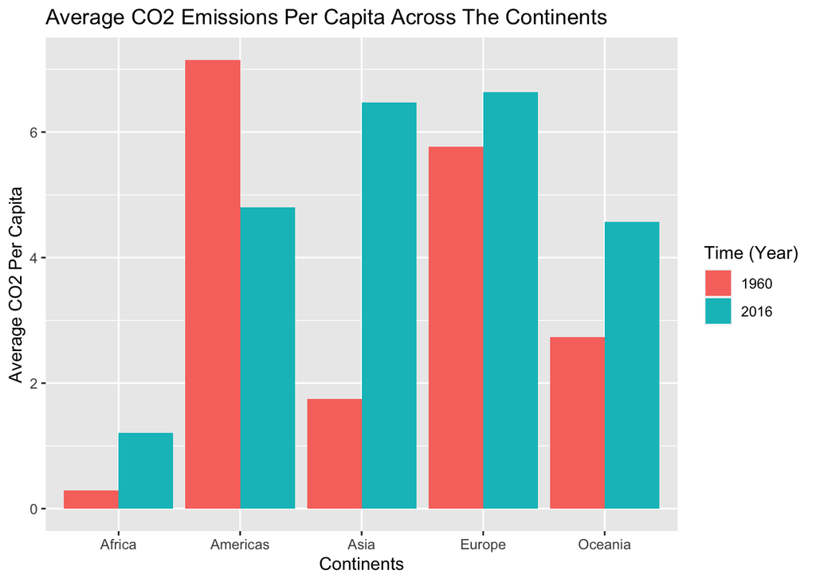

```r
ggplot(average_pc, aes(region, avgCO2, fill=factor(time))) +
  geom_col(position = "dodge") +
  labs(title = "Average CO2 Emissions Per Capita Across The Continents",
           x = "Continents",
           y = "Average CO2 Per Capita",
           fill = "Time (Year)")
```

### Question 3.6

```r
co2_emitters <- world %>%
  select(region, name, co2_PC, time) %>%
  filter(time == "2016", !is.na(region), !is.na(co2_PC)) %>%
  arrange(region, desc(co2_PC)) %>%
  group_by(region)
```

```r
co2_emitters %>%
  top_n(3, co2_PC) %>%
  head(6)
```

```
## # A tibble: 6 × 4
## # Groups:   region [2]
##   region   name                     co2_PC  time
##   <chr>    <chr>                     <dbl> <dbl>
## 1 Africa   South Africa               8.48  2016
## 2 Africa   Libya                      7.79  2016
## 3 Africa   Seychelles                 6.39  2016
## 4 Americas Trinidad and Tobago       31.8   2016
## 5 Americas United States of America  15.5   2016
## 6 Americas Canada                    15.1   2016
```

## Part 4

### Question 4.1

```r
gdp_1960 <- world %>%
  group_by(name) %>%
  filter(!is.na(GDP_PC), !is.na(lifeExpectancy)) %>%
  select(region, GDP_PC, lifeExpectancy, totalPopulation, time) %>%
  filter(time == "1960")
```

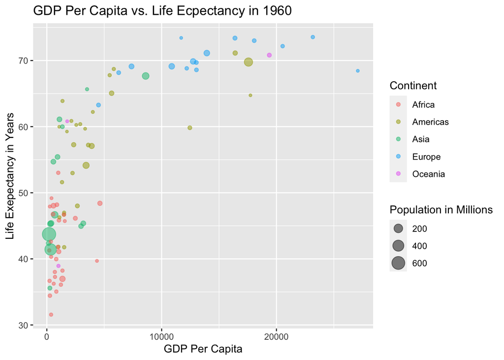

```r
ggplot(gdp_1960, aes(GDP_PC, lifeExpectancy, size = totalPopulation/1000000, col = factor(region))) +
  geom_point(alpha=0.5) +
  labs(x = "GDP Per Capita",
       y = "Life Exepectancy in Years",
       title = "GDP Per Capita vs. Life Ecpectancy in 1960",
       color = "Continent",
       size = "Population in Millions")
```

Looking at the scatterplot above, Europe and America have the highest GDP per capita which increases their life expectancy’s. This graph shows the relationship between life expectancy and GDP per capita.

### Question 4.2

```r
gdp_2019 <- world %>%
  group_by(name) %>%
  filter(!is.na(GDP_PC), !is.na(lifeExpectancy)) %>%
  select(region, GDP_PC, lifeExpectancy, totalPopulation, time) %>%
  filter(time == "2019")
```

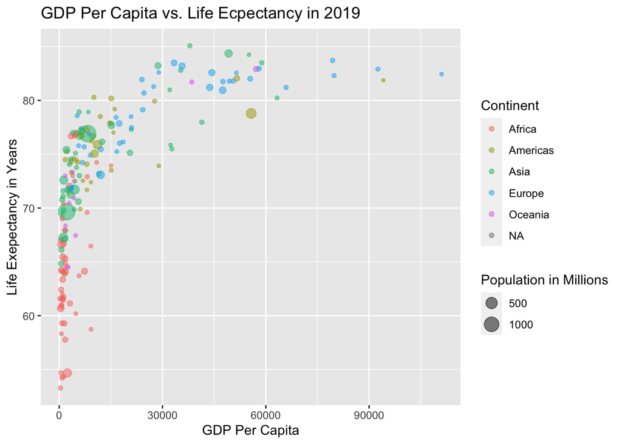

```r
ggplot(gdp_2019, aes(GDP_PC, lifeExpectancy, size = totalPopulation/1000000, col = factor(region))) +
  geom_point(alpha=0.5) +
  labs(x = "GDP Per Capita",
       y = "Life Exepectancy in Years",
       title = "GDP Per Capita vs. Life Ecpectancy in 2019",
       color = "Continent",
       size = "Population in Millions")
```

### Question 4.3

Over the last 60 years, the world has increased its population, thus the life expectancy has increased for each region. Similar to the GDP per capita, it has increased. When we compare these two plots together, it shows us that as the population increases, the GDP per capita and life expectancy increases. However, the overall trend of these two plots remain somewhat similar.

### Question 4.4

```r
world %>%
  group_by(region) %>%
  filter(!is.na(lifeExpectancy)) %>%
  select(lifeExpectancy, time, region) %>%
  filter(time == "1960") %>%
  summarise(average_le_1960 = mean(lifeExpectancy))
```

```
## # A tibble: 6 × 2
##   region   average_le_1960
##   <chr>              <dbl>
## 1 Africa              41.5
## 2 Americas            58.6
## 3 Asia                51.6
## 4 Europe              68.3
## 5 Oceania             56.4
## 6 <NA>                70.7
```

```r
world %>%
  group_by(region) %>%
  filter(!is.na(lifeExpectancy)) %>%
  filter(region !="") %>%
  select(lifeExpectancy, time, region) %>%
  filter(time == "2019") %>%
  summarise(average_le_2019 = mean(lifeExpectancy))
```

```
## # A tibble: 5 × 2
##   region   average_le_2019
##   <chr>              <dbl>
## 1 Africa              64.1
## 2 Americas            75.8
## 3 Asia                74.6
## 4 Europe              79.4
## 5 Oceania             73.5
```

After computing the average life expectancy for each continent, I compared the numbers from 1960 and 2019, which show me that the life expectancy increased. This fits with my findings on the figures that I made where over the last 60 years, the world has increased its population, thus the life expectancy has increased for each region.

### Question 4.5

```r
world %>%
  select(region, lifeExpectancy, time) %>%
  filter(!is.na(region), !is.na(lifeExpectancy), !is.na(time)) %>%
  filter(time %in% c("1960", "2016")) %>%
  group_by(region, time) %>%
  summarise(average = mean(lifeExpectancy)) %>%
  mutate(previous = lag(average), growth = average - previous)
```

```
## # A tibble: 10 × 5
## # Groups:   region [5]
##    region    time average previous growth
##    <chr>    <dbl>   <dbl>    <dbl>  <dbl>
##  1 Africa    1960    41.5     NA     NA
##  2 Africa    2016    63.0     41.5   21.5
##  3 Americas  1960    58.6     NA     NA
##  4 Americas  2016    75.3     58.6   16.7
##  5 Asia      1960    51.6     NA     NA
##  6 Asia      2016    74.0     51.6   22.3
##  7 Europe    1960    68.3     NA     NA
##  8 Europe    2016    79.0     68.3   10.7
##  9 Oceania   1960    56.4     NA     NA
## 10 Oceania   2016    73.0     56.4   16.6
```

### Question 4.6

(6pt) Show the histogram of GDP per capita for years of 1960 and 2019. Try to put both histograms on the same graph, see how well you can do it!

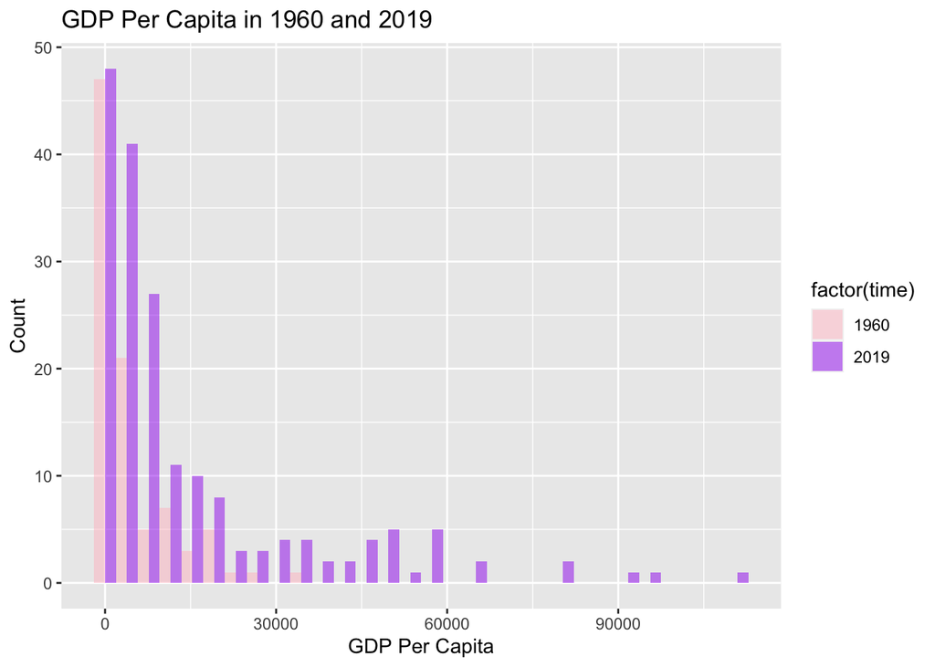

```r
world %>%
  filter(!is.na(GDP_PC)) %>%
  filter(time %in% c("1960", "2019")) %>%
  ggplot(aes(GDP_PC, fill = factor(time))) +
  geom_histogram(alpha = 0.5, position = "dodge", bins = 30) +
  scale_fill_manual(values = c("pink", "purple"), labels = c("1960", "2019")) +
  labs(x = "GDP Per Capita",
       y = "Count",
       title = "GDP Per Capita in 1960 and 2019")
```

### Question 4.7

```r
ranks <- world %>%
  select(name, lifeExpectancy, time) %>%
  filter(!is.na(lifeExpectancy), !is.na(name), time %in% c("1960", "2019")) %>%
  arrange(time, desc(lifeExpectancy)) %>%
  group_by(time) %>%
  mutate(rankings = rank(desc(lifeExpectancy)))

ranks %>%
  filter(name == "United States of America")
```

```
## # A tibble: 2 × 4
## # Groups:   time [2]
##   name                     lifeExpectancy  time rankings
##   <chr>                             <dbl> <dbl>    <dbl>
## 1 United States of America           69.8  1960       17
## 2 United States of America           78.8  2019       46
```

### Question 4.8

```r
ranks %>%
  select(name, time, rankings) %>%
  group_by(time) %>%
  mutate(total_n = max(rankings)) %>%
  filter(name == "United States of America") %>%
  summarise(relativerank = rankings/total_n)
```

```
## # A tibble: 2 × 2
##    time relativerank
##   <dbl>        <dbl>
## 1  1960       0.0904
## 2  2019       0.235
```

### Last Question

I spent about 16 hours on this assignment.